# *GR5074 Assignment 1: Write up a report on U.N. World Happiness Data.*

# *Adrian Wang*

https://github.com/Wangosteen

```python
import matplotlib.pyplot as plt
import pandas as pd
import numpy as np
import seaborn as sns
from zipfile import ZipFile
```

```python
! pip install aimodelshare --upgrade
```

[output not shown]

```python
from zipfile import ZipFile
from google.colab import files
uploaded = files.upload()
```

Upload widget is only available when the cell has been executed in the current browser session. Please rerun this cell to enable.

```
Saving world_happiness_competition_data.zip to world_happiness_competition_data (2).zip
```

```python
with ZipFile('world_happiness_competition_data.zip') as myzip:
    myzip.extractall(".")
```

```python
import pandas as pd
X_train = pd.read_csv('world_happiness_competition_data/X_train.csv')
X_test = pd.read_csv('world_happiness_competition_data/X_test.csv')
y_train = pd.read_csv('world_happiness_competition_data/y_train.csv')
y_train_labels = y_train.idxmax(axis=1)

X_train.head()
```

|  | Country or region | GDP per capita | Social support | Healthy life expectancy | Freedom to make life choices | Generosity | Perceptions of corruption | name | region | sub-region | Terrorist_attacks |
| --- | --- | --- | --- | --- | --- | --- | --- | --- | --- | --- | --- |
| 0 | Peru | 0.960 | 1.274 | 0.854 | 0.455 | 0.083 | 0.027 | Peru | Americas | Latin America and the Caribbean | 18.000000 |
| 1 | Nicaragua | 0.694 | 1.325 | 0.835 | 0.435 | 0.200 | 0.127 | Nicaragua | Americas | Latin America and the Caribbean | 125.611111 |
| 2 | Greece | 1.181 | 1.156 | 0.999 | 0.067 | 0.000 | 0.034 | Greece | Europe | Southern Europe | 112.000000 |
| 3 | Qatar | 1.684 | 1.313 | 0.871 | 0.555 | 0.220 | 0.167 | Qatar | Asia | Western Asia | 57.333333 |
| 4 | Uzbekistan | 0.745 | 1.529 | 0.756 | 0.631 | 0.322 | 0.240 | Uzbekistan | Asia | Central Asia | 125.611111 |

```python
X_train = X_train.drop(['Country or region', 'name'], axis=1)
print(X_train.columns)
X_test = X_test.drop(['Country or region', 'name'], axis=1)
```

```
Index(['GDP per capita', 'Social support', 'Healthy life expectancy',
       'Freedom to make life choices', 'Generosity',
       'Perceptions of corruption', 'region', 'sub-region',
       'Terrorist_attacks'],
      dtype='object')
```

```python
from sklearn.preprocessing import StandardScaler, OneHotEncoder
from sklearn.compose import ColumnTransformer, make_column_transformer
from sklearn.pipeline import Pipeline
from sklearn.impute import SimpleImputer
from sklearn.preprocessing import StandardScaler, OneHotEncoder

numeric_features = X_train.drop(['region', 'sub-region'], axis=1)
numeric_features=numeric_features.columns.tolist()

numeric_transformer = Pipeline(steps=[
    ('imputer', SimpleImputer(strategy='median')),
    ('scaler', StandardScaler())])

categorical_features = ['region', 'sub-region']

categorical_transformer = Pipeline(steps=[
    ('imputer', SimpleImputer(strategy='most_frequent')),
    ('onehot', OneHotEncoder(handle_unknown='ignore'))])

preprocessor = ColumnTransformer(
    transformers=[
        ('num', numeric_transformer, numeric_features),
        ('cat', categorical_transformer, categorical_features)])

preprocess=preprocessor.fit(X_train)
```

```python
def preprocessor(data):
    preprocessed_data=preprocess.transform(data)
    return preprocessed_data
```

## 1. Explore bivariate results (Use visualizations!). Describe any relationships you see between particular features and the target variable.

```python
y_train_labels = pd.Categorical(y_train_labels,
                                categories=['Very Low', 'Low', 'Average', 'High', 'Very High'],
                                ordered=True)
```

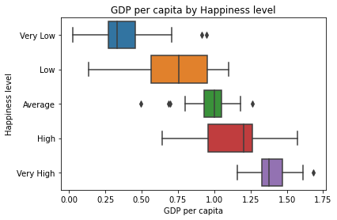

```python
sns.boxplot(x= X_train['GDP per capita'], y= y_train_labels)
plt.title("GDP per capita by Happiness level")
plt.ylabel('Happiness level')
```

As it can be seen from the diagram above, there is a strong positive relationship between GDP per capita and happiness level. As GDP per capita increases, happiness level increases. Notably, there exists a substantial difference between the mean of very high levels of happiness and the mean of very low levels of happiness.

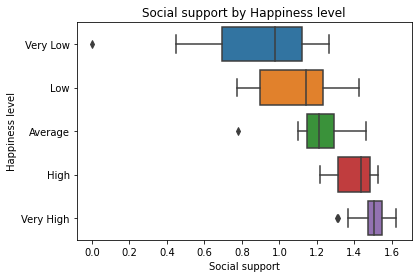

```python
sns.boxplot(x= X_train['Social support'], y= y_train_labels)
plt.title("Social support by Happiness level")
plt.ylabel('Happiness level')
```

As it can be seen from the diagram above, there is a strong positive relationship between social support and happiness level. As social support increases, happiness level increases. That being said, the differential in means is considerably lower than that of the first diagram, indicating that GDP per capita may have a larger impact on happiness levels than social support.

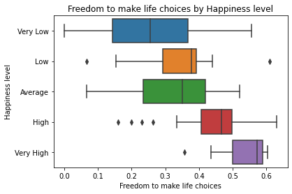

```python
sns.boxplot(x=X_train['Freedom to make life choices'], y=y_train_labels)
plt.title("Freedom to make life choices by Happiness level")
plt.ylabel('Happiness level')
```

# 2. Examine features that predict happiness categories using one or more models that allow for automatic feature selection. Explain any meaningful findings.

```python
from sklearn.ensemble import RandomForestClassifier
model = RandomForestClassifier(n_estimators=300, max_depth=3)
model.fit(preprocessor(X_train), y_train_labels)
model.score(preprocessor(X_train), y_train_labels)
```

```
0.8409090909090909
```

```python
importance = model.feature_importances_
print(importance)
```

```
[0.19297042 0.14530859 0.18085221 0.09218833 0.06671584 0.09470172
 0.06506919 0.02821518 0.00635391 0.00912386 0.01252323 0.00078404
 0.00048709 0.00080417 0.00179962 0.00485161 0.01190378 0.00597094
 0.00058769 0.00401479 0.00357367 0.00415712 0.00513715 0.04795336
 0.00275252 0.01119998]
```

```python
from sklearn.feature_selection import SelectFromModel
select = SelectFromModel(RandomForestClassifier(n_estimators=200, max_depth=2), threshold=0.1)
select.fit(preprocessor(X_train), y_train_labels)
X_train_selected = select.transform(preprocessor(X_train))
X_train.columns[select.get_support(indices=True)].tolist()
```

```
['GDP per capita', 'Social support', 'Healthy life expectancy']
```

In order to examine features that predict happiness categories, I utilised a random forest classifier moddel to filter the categories that were more important. Through this analysis, I found that GDP per capita, social support, and healthy life expectancy were three crucial factors that had a relatively high feature importance. These findings can be partially suppored by the illustrations above.

# 3. Experiment with different prediction models to try to predict World Happiness well (Fit and compare, at minimum, three models).

# Submit three models to the model share leaderboard before you start communicating with your team.

I experimented with three different prediction models to try to predict World Happiness - namely, these were random forest classifier, keras, and gradient boosting classifier. GridsearchCV was applied to all models, allowing me to compare their best mean cross-validation score and training set score with best parameters. In this regard, random forest classifier had a best mean CV score of 0.705 and training set score of 0.9432. Keras had a best mean CV score of 0.658 and training set score of 0.8864. Gradient boosting classifier had a best mean cross-validation score of 0.620 and a training set score with best parameters of 1.0. Hence, it can be seen that random forest classifier had the highest best mean CV score, while gradient boosting classifier had the highest training set score.

# RandomForestClassifier

```python
from sklearn.ensemble import RandomForestClassifier
from sklearn.model_selection import GridSearchCV
param_grid = {'n_estimators': np.arange(300, 500, 800),'max_depth':[3, 5, 8],'criterion': ['gini', 'entropy']}
gridmodel = GridSearchCV(RandomForestClassifier(), param_grid=param_grid, cv=10)
gridrfc= GridSearchCV(RandomForestClassifier(random_state=8), param_grid=param_grid).fit(preprocessor(X_train), y_train_labels)
print("Best parameters: {}".format(gridrfc.best_params_))
print("Best mean cross-validation score: {:.3f}".format(gridrfc.best_score_))
print("Training set score with best parameters: {:.4f}".format(gridrfc.score(preprocessor(X_train), y_train_labels)))
```

```
Best parameters: {'criterion': 'gini', 'max_depth': 5, 'n_estimators': 300}
Best mean cross-validation score: 0.705
Training set score with best parameters: 0.9432
```

```python
from sklearn.ensemble import RandomForestClassifier
model = RandomForestClassifier(n_estimators=300, max_depth=5, criterion='gini')
model.fit(preprocessor(X_train), y_train_labels)
model.score(preprocessor(X_train), y_train_labels)
```

```
0.9318181818181818
```

```python
import aimodelshare as ai
ai.export_preprocessor(preprocessor,"")
```

```
Your preprocessor is now saved to 'preprocessor.zip'
```

```python
from aimodelshare.aimsonnx import model_to_onnx

from skl2onnx.common.data_types import FloatTensorType

feature_count=preprocessor(X_test).shape[1]
initial_type = [('float_input', FloatTensorType([None, feature_count]))]

onnx_model = model_to_onnx(model, framework='sklearn',
                          initial_types=initial_type,
                          transfer_learning=False,
                          deep_learning=False)

with open("model.onnx", "wb") as f:
    f.write(onnx_model.SerializeToString())
```

```python
from aimodelshare.aws import set_credentials

apiurl="https://e2w6gh3id1.execute-api.us-east-2.amazonaws.com/prod/m"

set_credentials(apiurl=apiurl)
```

```
AI Modelshare Username:··········
AI Modelshare Password:··········
AI Model Share login credentials set successfully.
```

```python
import aimodelshare as ai
mycompetition= ai.Competition(apiurl)
```

```python
prediction_labels = model.predict(preprocessor(X_test))

mycompetition.submit_model(model_filepath = "model.onnx",
                                 preprocessor_filepath="preprocessor.zip",
                                 prediction_submission=prediction_labels,
                           custom_metadata={"team":"7"})
```

```
Insert search tags to help users find your model (optional):
Provide any useful notes about your model (optional):

Your model has been submitted as model version 419

To submit code used to create this model or to view current leaderboard navigate to Model Playground:

 https://www.modelshare.org/detail/model:3164
```

## Keras

```python
import keras
from keras.models import Sequential
from keras.layers import Dense, Activation
```

```python
def create_model(hiddennodes_1=10, hiddennodes_2=10, hiddennodes_3=10):
    model = Sequential()
    model.add(Dense(hiddennodes_1, input_dim=26, activation='relu'))
    model.add(Dense(hiddennodes_2, activation='relu'))
    model.add(Dense(hiddennodes_3, activation='relu'))
    model.add(Dense(5, activation='softmax'))
    model.compile(loss='categorical_crossentropy', optimizer='sgd', metrics=['accuracy'])
    return model
```

```python
from tensorflow.keras.wrappers.scikit_learn import KerasClassifier
from sklearn.model_selection import GridSearchCV

keras = KerasClassifier(build_fn=create_model, epochs=300, batch_size=20, verbose=0)
keras_param_grid = {'hiddennodes_1': [20, 30, 40],
                    'hiddennodes_2': [20, 30, 40],
                    'hiddennodes_3': [20, 30, 40]}
keras_grid = GridSearchCV(keras, param_grid=keras_param_grid)
keras_grid.fit(preprocessor(X_train), y_train)
print("Best parameters: {}".format(keras_grid.best_params_))
print("Best mean cross-validation score: {:.3f}".format(keras_grid.best_score_))
print("Training set score with best parameters: {:.4f}".format(keras_grid.score(preprocessor(X_train), y_train)))
```

```
Best parameters: {'hiddennodes_1': 40, 'hiddennodes_2': 30, 'hiddennodes_3': 30}
Best mean cross-validation score: 0.658
Training set score with best parameters: 0.8864
```

```python
model_2 = Sequential()
model_2.add(Dense(40, input_dim=26, activation='relu'))
model_2.add(Dense(30, activation='relu'))
model_2.add(Dense(30, activation='relu'))
model_2.add(Dense(5, activation='softmax'))
model_2.compile(loss='categorical_crossentropy', optimizer='sgd', metrics=['accuracy'])
model_2.fit(preprocessor(X_train), y_train,
               batch_size = 20,
               epochs = 300, validation_split=0.25)
```

```
<keras.callbacks.History at 0x7feff8e00400>
```

```python
from aimodelshare.aimsonnx import model_to_onnx

onnx_model = model_to_onnx(model_2, framework='keras',
                          transfer_learning=False,
                          deep_learning=True)

with open("model.onnx", "wb") as f:
    f.write(onnx_model.SerializeToString())
```

```python
prediction_column_index=model_2.predict(preprocessor(X_test)).argmax(axis=1)
prediction_labels = [y_train.columns[i] for i in prediction_column_index]
mycompetition.submit_model(model_filepath = "model.onnx",
                                 preprocessor_filepath="preprocessor.zip",
                                 prediction_submission=prediction_labels,
                           custom_metadata={"team":"7"})
```

```
Insert search tags to help users find your model (optional):
Provide any useful notes about your model (optional):

Your model has been submitted as model version 421

To submit code used to create this model or to view current leaderboard navigate to Model Playground:

 https://www.modelshare.org/detail/model:3164
```

# GradientBoostingClassifier

```python
from sklearn.ensemble import GradientBoostingClassifier
param_grid = {'n_estimators': [300, 400 , 500],
             "max_depth":[3,4,5],
             "learning_rate":[.001,.01,.1]}

gridgb = GridSearchCV(GradientBoostingClassifier(random_state=9),
                    param_grid=param_grid, cv=5, scoring='f1_macro')
gridgb.fit(preprocessor(X_train), y_train_labels)
print("Best parameters: {}".format(gridgb.best_params_))
print("Best mean cross-validation score: {:.3f}".format(gridgb.best_score_))
print("Training set score with best parameters: {:.4f}".format(gridgb.score(preprocessor(X_train), y_train_labels)))
```

```
Best parameters: {'learning_rate': 0.01, 'max_depth': 5, 'n_estimators': 300}
Best mean cross-validation score: 0.620
Training set score with best parameters: 1.0000
```

```python
model = GradientBoostingClassifier(n_estimators=300, learning_rate=0.01,
    max_depth=5, random_state=0).fit(preprocessor(X_train), y_train_labels)
model.score(preprocessor(X_train), y_train_labels)

from aimodelshare.aimsonnx import model_to_onnx

feature_count=preprocessor(X_test).shape[1]
initial_type = [('float_input', FloatTensorType([None, feature_count]))]

onnx_model = model_to_onnx(model, framework='sklearn',
                          initial_types=initial_type,
                          transfer_learning=False,
                          deep_learning=False)

with open("model.onnx", "wb") as f:
    f.write(onnx_model.SerializeToString())

prediction_labels = model.predict(preprocessor(X_test))

mycompetition.submit_model(model_filepath = "model.onnx",
                                 preprocessor_filepath="preprocessor.zip",
                                 prediction_submission=prediction_labels,
                           custom_metadata={"team":"7"})
```

```
Insert search tags to help users find your model (optional):
Provide any useful notes about your model (optional):

Your model has been submitted as model version 423

To submit code used to create this model or to view current leaderboard navigate to Model Playground:

 https://www.modelshare.org/detail/model:3164
```

# 4. Fit and submit up to three more models after learning from your team. Discuss which models you tried and which models performed better and point out relevant hyper-parameter values for successful models.

# Submit your best models to the leaderboard for the World Happiness AI Model Share competition.

During the discussion with my team, we spoke about independent variables being outliers, and exploring feature engineering. We found that some best performing models included gradient boosting with high learning rate and low max depth, and random forest classifier with a max_depth of 5 and n_estimators of 100 or 1000.

```python
from sklearn.ensemble import RandomForestClassifier
model_4 = RandomForestClassifier(n_estimators=1000, max_depth=5, criterion='gini')
model_4.fit(preprocessor(X_train), y_train_labels)
model_4.score(preprocessor(X_train), y_train_labels)
```

```
0.9431818181818182
```

```python
import aimodelshare as ai
ai.export_preprocessor(preprocessor,"")
```

```
Your preprocessor is now saved to 'preprocessor.zip'
```

```python
from aimodelshare.aimsonnx import model_to_onnx

feature_count=preprocessor(X_test).shape[1]
initial_type = [('float_input', FloatTensorType([None, feature_count]))]

onnx_model = model_to_onnx(model_4, framework='sklearn',
                          initial_types=initial_type,
                          transfer_learning=False,
                          deep_learning=False)

with open("model4.onnx", "wb") as f:
    f.write(onnx_model.SerializeToString())
```

```python
prediction_labels = model_4.predict(preprocessor(X_test))

mycompetition.submit_model(model_filepath = "model4.onnx",
                                 prediction_submission=prediction_labels,
                                 preprocessor_filepath="preprocessor.zip")
```

```
Insert search tags to help users find your model (optional):
Provide any useful notes about your model (optional):

Your model has been submitted as model version 426

To submit code used to create this model or to view current leaderboard navigate to Model Playground:

 https://www.modelshare.org/detail/model:3164
```

```python
from sklearn.ensemble import RandomForestClassifier
model_5 = RandomForestClassifier(n_estimators=1000, max_depth=10, criterion='gini')
model_5.fit(preprocessor(X_train), y_train_labels)
model_5.score(preprocessor(X_train), y_train_labels)
```

```
1.0
```

```python
import aimodelshare as ai
ai.export_preprocessor(preprocessor,"")
```

```
Your preprocessor is now saved to 'preprocessor.zip'
```

```python
from aimodelshare.aimsonnx import model_to_onnx

feature_count=preprocessor(X_test).shape[1]
initial_type = [('float_input', FloatTensorType([None, feature_count]))]

onnx_model = model_to_onnx(model_5, framework='sklearn',
                          initial_types=initial_type,
                          transfer_learning=False,
                          deep_learning=False)

with open("model5.onnx", "wb") as f:
    f.write(onnx_model.SerializeToString())
```

```python
prediction_labels = model_5.predict(preprocessor(X_test))

mycompetition.submit_model(model_filepath = "model5.onnx",
                                 prediction_submission=prediction_labels,
                                 preprocessor_filepath="preprocessor.zip")
```

```
Insert search tags to help users find your model (optional):
Provide any useful notes about your model (optional):

Your model has been submitted as model version 427

To submit code used to create this model or to view current leaderboard navigate to Model Playground:

 https://www.modelshare.org/detail/model:3164
```

```python
from sklearn.ensemble import GradientBoostingClassifier
model_6 = GradientBoostingClassifier(n_estimators=200, learning_rate=0.1,
    max_depth=1, random_state=0).fit(preprocessor(X_train), y_train_labels)
model_6.score(preprocessor(X_train), y_train_labels)

from aimodelshare.aimsonnx import model_to_onnx

feature_count=preprocessor(X_test).shape[1]
initial_type = [('float_input', FloatTensorType([None, feature_count]))]

onnx_model = model_to_onnx(model_6, framework='sklearn',
                          initial_types=initial_type,
                          transfer_learning=False,
                          deep_learning=False)

with open("model6.onnx", "wb") as f:
    f.write(onnx_model.SerializeToString())

prediction_labels = model_6.predict(preprocessor(X_test))

mycompetition.submit_model(model_filepath = "model6.onnx",
                                 preprocessor_filepath="preprocessor.zip",
                                 prediction_submission=prediction_labels,
                           custom_metadata={"team":"7"})
```

```
Insert search tags to help users find your model (optional):
Provide any useful notes about your model (optional):

Your model has been submitted as model version 430

To submit code used to create this model or to view current leaderboard navigate to Model Playground:

 https://www.modelshare.org/detail/model:3164
```

```python
data = mycompetition.get_leaderboard()

mycompetition.stylize_leaderboard(data)
```

|  | accuracy | f1_score | precision | recall | ml_framework | transfer_learning | deep_learning | model_type | depth | num_params | flatten_layers | batchnormalization_layers | dropout_layers | dense_layers | sigmoid_act | relu_act | tanh_act | softmax_act | loss | optimizer | memory_size | team | username | version |
| --- | --- | --- | --- | --- | --- | --- | --- | --- | --- | --- | --- | --- | --- | --- | --- | --- | --- | --- | --- | --- | --- | --- | --- | --- |
| 0 | 58.82% | 57.65% | 65.59% | 59.50% | sklearn | False | False | GradientBoostingClassifier | nan | nan | nan | nan | nan | nan | nan | nan | nan | nan | nan | nan | nan | four | ran_liao | 299 |
| 1 | 55.88% | 51.89% | 69.50% | 56.64% | sklearn | False | False | GradientBoostingClassifier | nan | nan | nan | nan | nan | nan | nan | nan | nan | nan | nan | nan | nan | 6 | francesyang | 305 |
| 2 | 55.88% | 51.89% | 69.50% | 56.64% | sklearn | False | False | GradientBoostingClassifier | nan | nan | nan | nan | nan | nan | nan | nan | nan | nan | nan | nan | nan | 6 | francesyang | 312 |
| 3 | 58.82% | 57.65% | 65.59% | 59.50% | sklearn | False | False | GradientBoostingClassifier | nan | nan | nan | nan | nan | nan | nan | nan | nan | nan | nan | nan | nan | nan | yatharth | 58 |
| 4 | 55.88% | 51.89% | 69.50% | 56.64% | sklearn | False | False | GradientBoostingClassifier | nan | nan | nan | nan | nan | nan | nan | nan | nan | nan | nan | nan | nan | 6 | francesyang | 324 |
| 5 | 55.88% | 51.89% | 69.50% | 56.64% | sklearn | False | False | GradientBoostingClassifier | nan | nan | nan | nan | nan | nan | nan | nan | nan | nan | nan | nan | nan | nan | yatharth | 66 |
| 6 | 55.88% | 51.89% | 69.50% | 56.64% | sklearn | False | False | GradientBoostingClassifier | nan | nan | nan | nan | nan | nan | nan | nan | nan | nan | nan | nan | nan | 6 | francesyang | 327 |
| 7 | 55.88% | 51.89% | 69.50% | 56.64% | sklearn | False | False | GradientBoostingClassifier | nan | nan | nan | nan | nan | nan | nan | nan | nan | nan | nan | nan | nan | nan | yatharth | 68 |
| 8 | 52.94% | 51.56% | 71.39% | 55.29% | sklearn | False | False | GaussianNB | nan | nan | nan | nan | nan | nan | nan | nan | nan | nan | nan | nan | nan | 6.0 | bobbie8881 | 125 |
| 9 | 52.94% | 51.56% | 71.39% | 55.29% | sklearn | False | False | RandomForestClassifier | nan | nan | nan | nan | nan | nan | nan | nan | nan | nan | nan | nan | nan | 6.0 | bobbie8881 | 123 |
| 10 | 52.94% | 50.96% | 72.38% | 55.29% | sklearn | False | False | RandomForestClassifier | nan | nan | nan | nan | nan | nan | nan | nan | nan | nan | nan | nan | nan | 5.0 | halfbaked_em | 127 |
| 11 | 52.94% | 51.56% | 71.39% | 55.29% | sklearn | False | False | RandomForestClassifier | nan | nan | nan | nan | nan | nan | nan | nan | nan | nan | nan | nan | nan | four | ran_liao | 288 |
| 12 | 52.94% | 50.00% | 69.39% | 56.43% | keras | False | True | Sequential | 3.000000 | 1539.000000 | nan | nan | nan | 3.000000 | nan | 2.000000 | nan | 1.000000 | str | SGD | 6968.000000 | 8 | hal2148 | 422 |
| 13 | 52.94% | 53.01% | 65.33% | 55.29% | keras | False | True | Sequential | 5.000000 | 20357.000000 | nan | nan | nan | 5.000000 | nan | 4.000000 | nan | 1.000000 | str | SGD | 82752.000000 | 4.0 | so2638 | 211 |
| 14 | 55.88% | 53.74% | 64.78% | 55.86% | sklearn | False | False | GradientBoostingClassifier | nan | nan | nan | nan | nan | nan | nan | nan | nan | nan | nan | nan | nan | nan | vincent | 393 |
| 15 | 55.88% | 55.63% | 63.33% | 57.00% | sklearn | False | False | SVC | nan | nan | nan | nan | nan | nan | nan | nan | nan | nan | nan | nan | nan | 9.0 | sofiazaidman | 14 |
| 16 | 52.94% | 51.25% | 65.11% | 55.29% | sklearn | False | False | RandomForestClassifier | nan | nan | nan | nan | nan | nan | nan | nan | nan | nan | nan | nan | nan | 2.0 | ivster | 29 |
| 17 | 52.94% | 51.25% | 65.11% | 55.29% | sklearn | False | False | RandomForestClassifier | nan | nan | nan | nan | nan | nan | nan | nan | nan | nan | nan | nan | nan | 9 | mymstella | 405 |
| 18 | 52.94% | 51.25% | 65.11% | 55.29% | sklearn | False | False | RandomForestClassifier | nan | nan | nan | nan | nan | nan | nan | nan | nan | nan | nan | nan | nan | nan | sm_5271 | 350 |
| 19 | 52.94% | 49.61% | 67.78% | 53.79% | sklearn | False | False | GradientBoostingClassifier | nan | nan | nan | nan | nan | nan | nan | nan | nan | nan | nan | nan | nan | 7.0 | lprockop | 246 |
| 20 | 52.94% | 50.61% | 64.21% | 55.29% | keras | False | True | Sequential | 7.000000 | 18117.000000 | 1.000000 | nan | 1.000000 | 5.000000 | nan | 4.000000 | nan | 1.000000 | str | Adam | 73792.000000 | 6.0 | sdp2158 | 213 |
| 21 | 50.00% | 50.23% | 66.11% | 51.29% | sklearn | False | False | GradientBoostingClassifier | nan | nan | nan | nan | nan | nan | nan | nan | nan | nan | nan | nan | nan | 5.0 | oliverhegi | 159 |
| 22 | 52.94% | 48.54% | 66.62% | 52.64% | sklearn | False | False | GradientBoostingClassifier | nan | nan | nan | nan | nan | nan | nan | nan | nan | nan | nan | nan | nan | 6 | francesyang | 328 |
| 23 | 50.00% | 48.71% | 67.34% | 51.29% | sklearn | False | False | GradientBoostingClassifier | nan | nan | nan | nan | nan | nan | nan | nan | nan | nan | nan | nan | nan | 5.0 | oliverhegi | 155 |
| 24 | 50.00% | 49.03% | 65.67% | 52.43% | sklearn | False | False | RandomForestClassifier | nan | nan | nan | nan | nan | nan | nan | nan | nan | nan | nan | nan | nan | 5.0 | halfbaked_em | 271 |
| 25 | 52.94% | 52.10% | 61.49% | 55.29% | sklearn | False | False | RandomForestClassifier | nan | nan | nan | nan | nan | nan | nan | nan | nan | nan | nan | nan | nan | 5.0 | Chen | 232 |
| 26 | 50.00% | 48.78% | 65.35% | 51.29% | sklearn | False | False | GradientBoostingClassifier | nan | nan | nan | nan | nan | nan | nan | nan | nan | nan | nan | nan | nan | 5.0 | halfbaked_em | 270 |
| 27 | 50.00% | 47.62% | 67.73% | 52.43% | sklearn | False | False | RandomForestClassifier | nan | nan | nan | nan | nan | nan | nan | nan | nan | nan | nan | nan | nan | 2.0 | amsay99 | 95 |
| 28 | 50.00% | 47.62% | 67.73% | 52.43% | sklearn | False | False | RandomForestClassifier | nan | nan | nan | nan | nan | nan | nan | nan | nan | nan | nan | nan | nan | nan | newusertest | 3 |
| 29 | 50.00% | 47.62% | 67.73% | 52.43% | sklearn | False | False | RandomForestClassifier | nan | nan | nan | nan | nan | nan | nan | nan | nan | nan | nan | nan | nan | 6.0 | francesyang | 57 |

[output cut: 400 more lines]